# Appendix: Acknowledgement of Generative AI Use

Author

Sinping CHAN

I acknowledge the use of [1] Gemini 3 Flash [2] ([https://gemini.google.com/](https://gemini.google.com/?authuser=3)) and [1] Claude Sonnet 4.6 [2] (https://claude.ai/) to [3] generate ideas, structure suggestions, draft initial outlines and rewrite text, and provide code enhancements that were [3] included within my final assessment in modified form. I entered the following prompts on 9 April 2026:

- [3] Structure the “Dataset Introduction” and “Dataset Description” sections to ensure a professional distinction between business context and technical data details. [4] I edited the drafts to ensure the specific dates (Sept 2024 – Feb 2026) and customer segments accurately reflected my dataset.
- [3] Refine the academic style, English phrasing, and professional terminology throughout the assignment, including the Introduction, Dataset Description, and Results sections, ensuring a “highly skewed distribution” was correctly explained. [4] I reviewed and modified the suggested text to ensure it accurately reflected my specific findings and maintained a consistent voice.
- [3] Develop code for data visualizations (Figures), specifically the LOESS smoothing plot, and provide advice on professional academic formatting such as removing internal titles and using Quarto cross-referencing. [4] I confirmed that the visualization parameters accurately represented the trends and distributions found in my data.
- [3] Generate R code and formatting for all tables, including the primary “ROI Summary Table” with conditional formatting (red text for negative ROI) and the granular “ROI Check” mini-table. [4] I cross-checked the outputted summary statistics against the raw data to ensure accuracy.
- [3] Troubleshoot technical issues regarding Quarto rendering (resolving “object not found” errors), cross-referencing, and Git connectivity within RStudio.
- **[3] Documentation of AI Interactions:** Due to technical limitations in the chat platform, the full log of my interactions is documented in three parts within the supplementary files:
  1. **Part 1:** Key interactions regarding data cleaning and initial visualization with Gemini are provided as screenshots in the following pages of this appendix.
  2. **Part 2:** Subsequent full conversation logs with Gemini are documented in the separate file: Gemini_chat.docx
  3. **Part 3:** Full conversation logs and specific prompt iterations with Claude can be found at the following link: [[HERE](https://claude.ai/share/3ae2791b-32fe-4d30-b1ab-ea2fac8d1a6d)]

### **Screenshots of Initial Gemini Interactions:**

#### R code for data cleaning

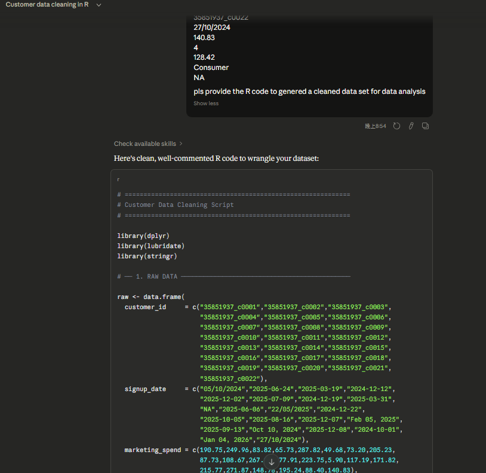

R code for data cleaning 1

#### Correct my tone and english writing in Dataset Introduction section git code for pushing, and check whether my writing is aligned to my code

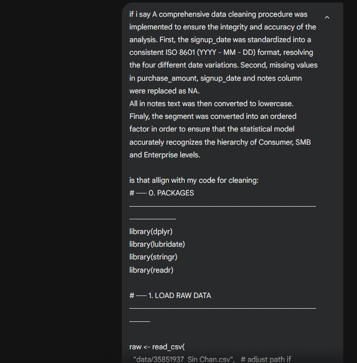

English writing and logic checking 1

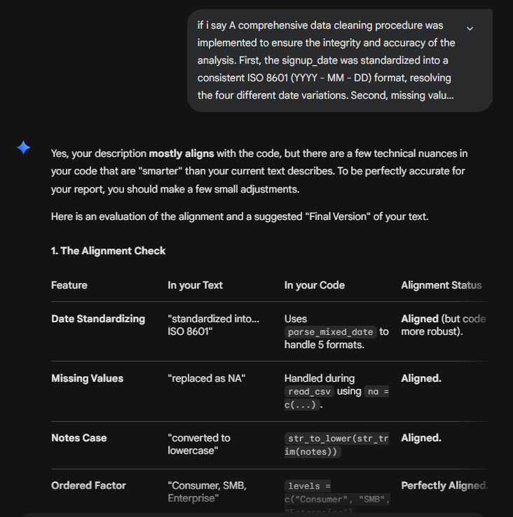

English writing and logic checking 2

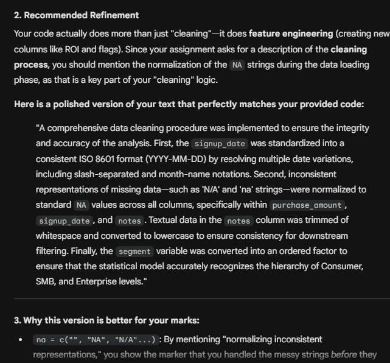

English writing and logic checking 3

#### R code for data size

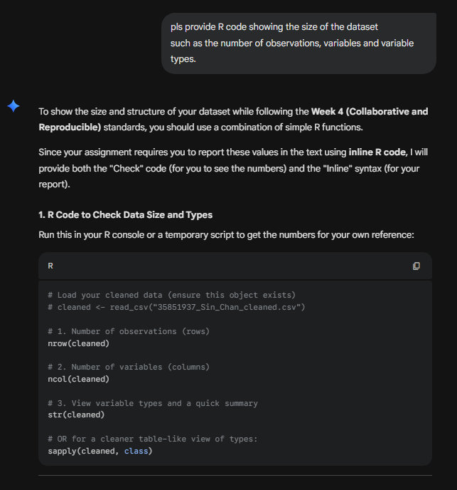

using AI to produce R code for data size

#### Correct my tone and English writing in Dataset Introduction section

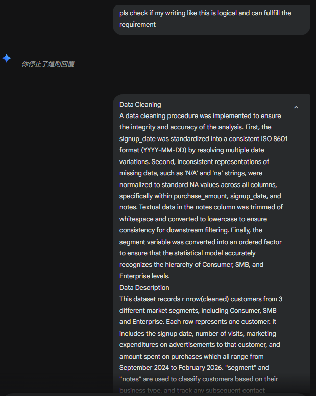

Eng writing -Dataset Introduction section 1

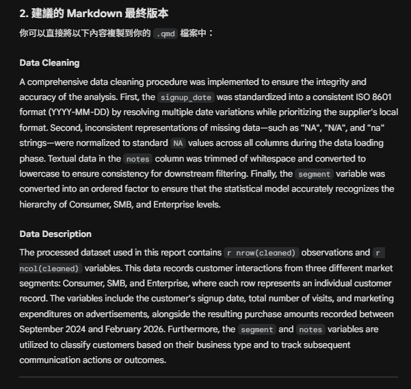

Eng writing -Dataset Introduction section 2

#### R code for Dataset summaries (plot and table)

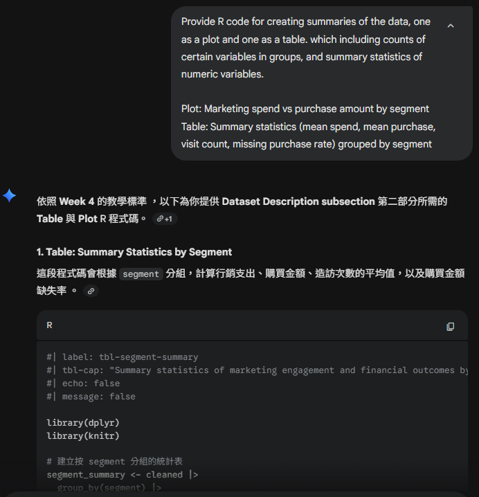

R code for Dataset summaries (plot and table) 1

#### Transform my ideas about the plot and table into a report writing style.

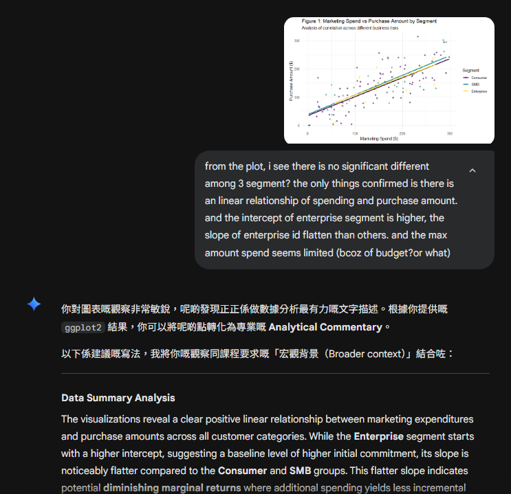

Transform my ideas about the plot and table into a report writing style. 1

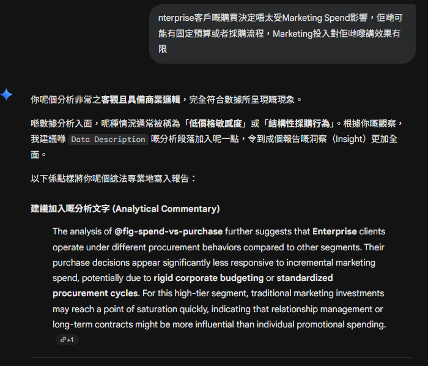

Transform my ideas about the plot and table into a report writing style. 2

#### R code for Result ( LOESS plot)

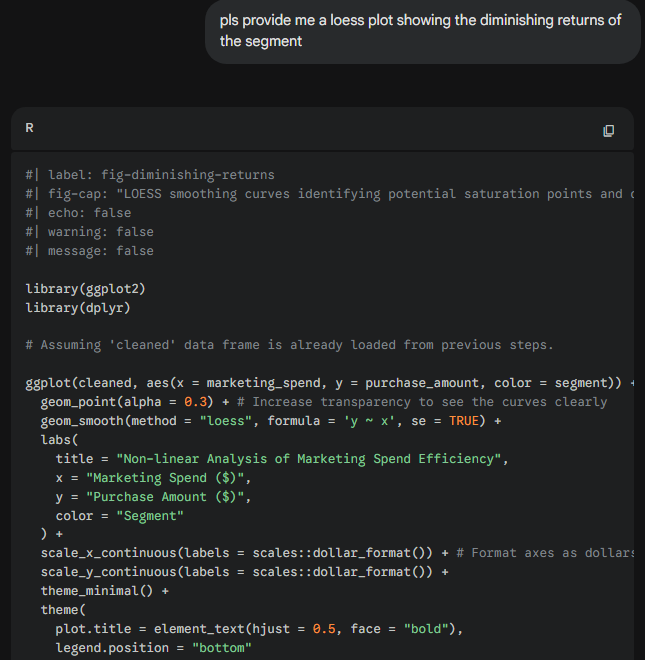

LOESS R CODE

#### Transform my ideas about the plot and table into a report writing style.

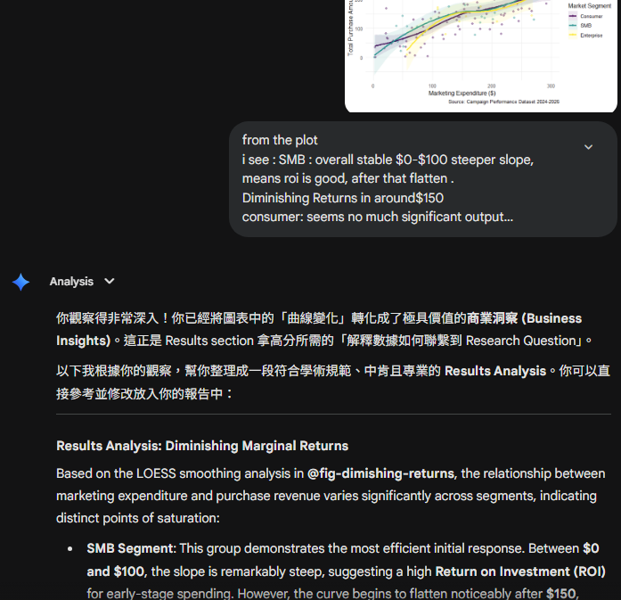

Transform my ideas about the plot and table into a report writing style. 1

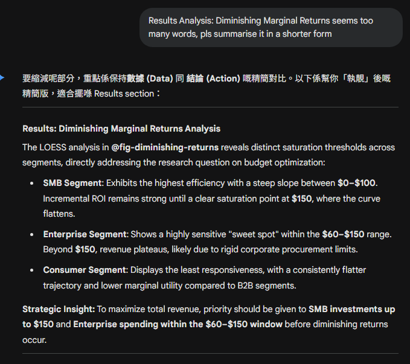

Transform my ideas about the plot and table into a report writing style. 2